# Assignment 1

Nickie Mitch

9/10/2020

## Loading libraries

```r
library(tidycensus)
library(tidyverse)
library(ggplot2)
library(ggthemes)
library(wesanderson)
```

## Reviewing variables

```r
area_vars_2010 <- load_variables(2010, "sf1")
```

## Selecting and loading variables

I chose to consider data from the 2010 Census for census tracts in my home county of Bartholomew County, Indiana. The continuous variables I consider are percent of households in rented homes (pct_rented), total households made up of only one person (tot_one_person_hh), the percent of housing units that are vacant (pct_vacant), and the total population of the tract (tot_pop). The categorical variables I consider are whether the tract is urban or rural (urban) and the majority gender of the tract (majority_gender). My data includes 15 observations.

```r
vars <- c(tot_housing_units = "H001001",
          tot_vacant = "H003003",
          tot_one_person_hh = "P019002",
          tot_rented = "H004004",
          tot_urban = "H002002",
          tot_pop = "P003001",
          tot_female = "P012026",
          tot_male = "P012002")
Barth_tracts <- get_decennial(geography = "tract", variables = vars,
                           state = "IN", county = "Bartholomew",
                           output = "wide") %>%
  mutate(urban = (tot_urban == tot_housing_units) ,
         pct_vacant = tot_vacant / tot_housing_units,
         pct_rented = tot_rented / tot_housing_units,
         majority_gender = case_when(
           tot_female / tot_pop > 0.5 ~ "female",
           tot_male / tot_pop > 0.5 ~ "male",
           TRUE ~ "None")) %>%
  filter(tot_pop > 0, tot_housing_units > 0) %>%
  select(GEOID, urban, majority_gender, pct_rented, pct_vacant, tot_one_person_hh, tot_pop)
```

## Displaying selected variables

```r
Barth_tracts
```

```
## # A tibble: 15 x 7
##    GEOID    urban majority_gender pct_rented pct_vacant tot_one_person_~ tot_pop
##    <chr>    <lgl> <chr>                <dbl>      <dbl>            <dbl>   <dbl>
##  1 1800501~ TRUE  male                0.569      0.149               789    4553
##  2 1800501~ TRUE  female              0.280      0.0696              549    4483
##  3 1800501~ TRUE  female              0.0892     0.0428              223    3486
##  4 1800501~ FALSE female              0.236      0.0995              525    5941
##  5 1800501~ TRUE  female              0.225      0.0883              534    5245
##  6 1800501~ TRUE  female              0.428      0.0715             1027    5245
##  7 1800501~ TRUE  female              0.460      0.144               553    3297
##  8 1800501~ FALSE female              0.516      0.0958              455    4071
##  9 1800501~ FALSE male                0.255      0.149               518    4827
## 10 1800501~ FALSE male                0.147      0.118               307    5033
## 11 1800501~ FALSE male                0.135      0.104               609    8436
## 12 1800501~ FALSE male                0.180      0.0838              403    5435
## 13 1800501~ FALSE male                0.0977     0.0494              301    4970
## 14 1800501~ FALSE male                0.153      0.0893              289    4170
## 15 1800501~ FALSE male                0.123      0.0932              476    7602
```

## Figure 1 - Scatterplot with all variables

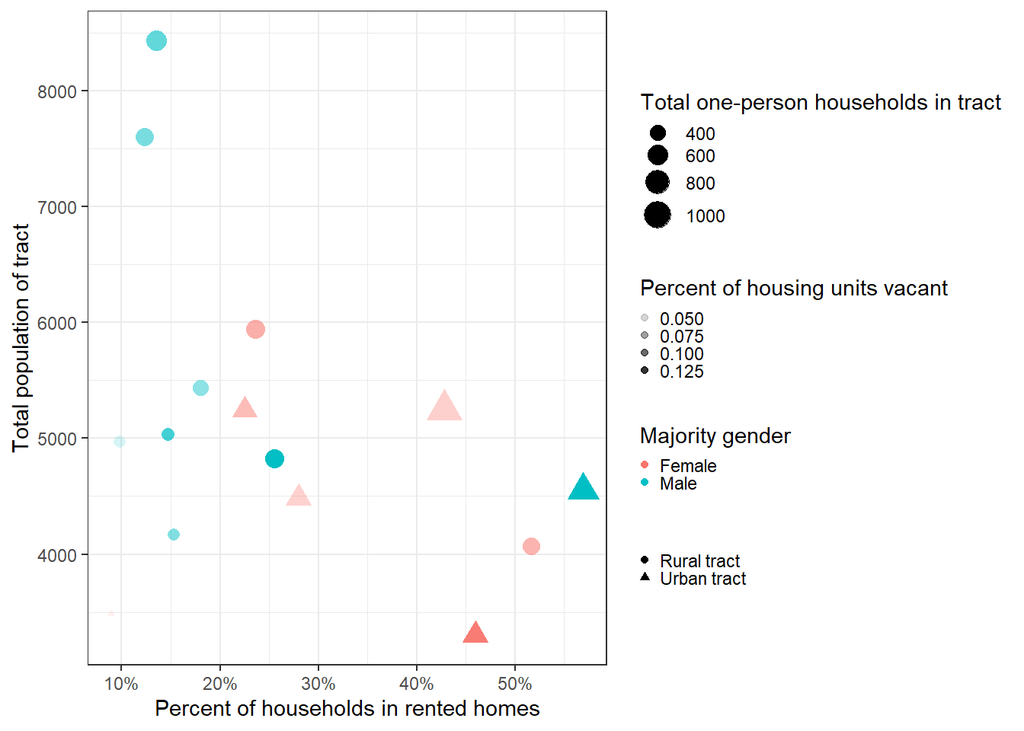

```r
ggplot(Barth_tracts,
       aes(x = pct_rented,
           y = tot_pop,
           size = tot_one_person_hh,
           shape = urban,
           color = majority_gender,
           alpha = pct_vacant )) +
  geom_point() +
  scale_size_continuous(name = "Total one-person households in tract") +
  scale_x_continuous(name = "Percent of households in rented homes",
                     breaks = seq(0, 1, by = 0.1),
                     labels = paste(seq(0, 100, by = 10), "%", sep = "")) +
  scale_y_continuous(name = "Total population of tract",
                     breaks = seq(0, 10000, by = 1000),
                     labels = paste(seq(0, 10000, by = 1000), sep = "")) +
  scale_color_discrete(name = "Majority gender",
                       labels = c("Female",
                       "Male")) +
  scale_alpha_continuous(name = "Percent of housing units vacant") +
   scale_shape(name = element_blank(),
              labels = c("Rural tract", "Urban tract")) +
  theme_bw() +
  theme(legend.key.size = unit(0.1, "cm"))
```

## Figure 2 - Bar chart with all categorical variables

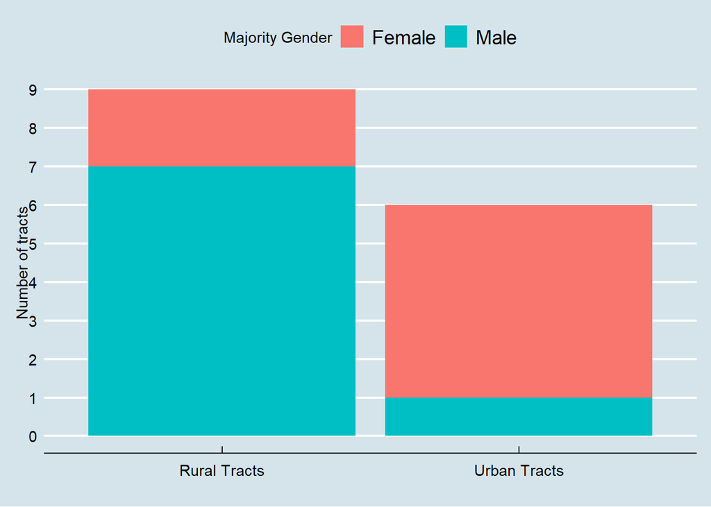

```r
ggplot(Barth_tracts, aes(x = urban, fill = majority_gender)) +
  geom_bar() +
  scale_y_continuous(name = "Number of tracts",
                     breaks = seq(0, 10, by = 1),) +
  scale_x_discrete(name = "",
                        labels = c("Rural Tracts",
                                   "Urban Tracts")) +
  scale_fill_discrete(name = "Majority Gender",
                        labels = c("Female",
                                   "Male")) +
  theme_economist()
```

## Figure 3 - Scatterplot with three continuous variable

[output not shown]

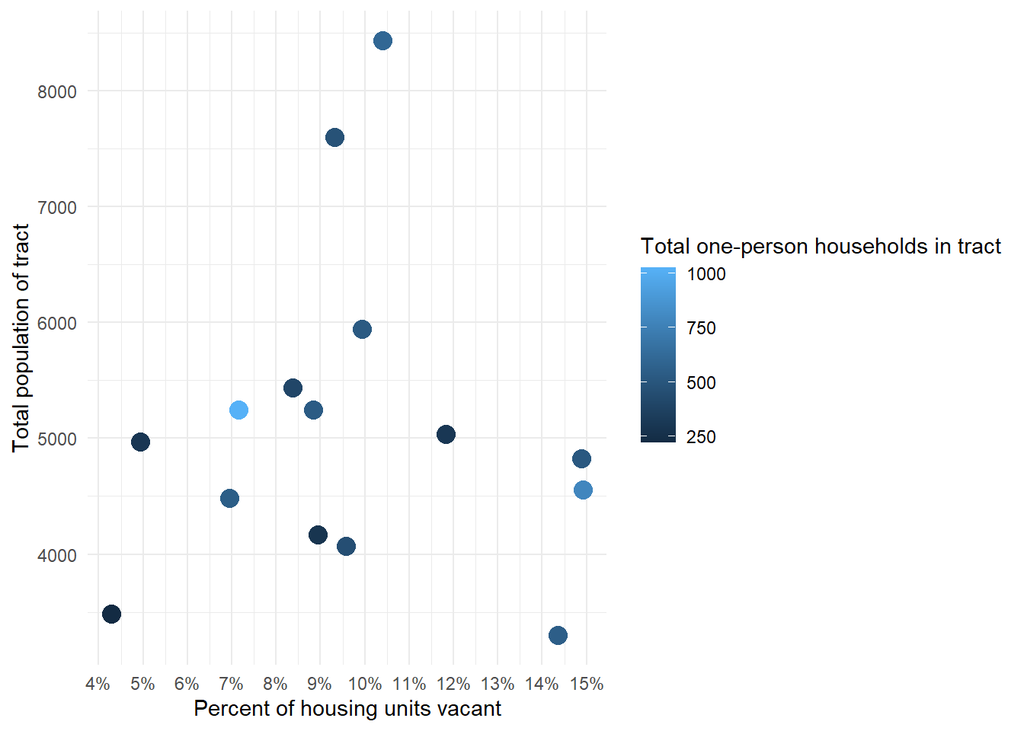

```r
ggplot(Barth_tracts,
       aes(x = pct_vacant,
           y = tot_pop,
           color = tot_one_person_hh)) +
  geom_point(size=4) +
  scale_color_manual(values=wes_palette(n=4, name="Moonrise2")) +
  scale_x_continuous(name = "Percent of housing units vacant",
                     breaks = seq(0, 1, by = 0.01),
                     labels = paste(seq(0, 100, by = 1), "%", sep = "")) +
  scale_y_continuous(name = "Total population of tract",
                     breaks = seq(1000, 10000, by = 1000)) +
  scale_color_continuous(name = "Total one-person households in tract",
                     breaks = seq(0, 1000, by = 250)) +
  theme_minimal()
```

## Figure 4 - Scatterplot with one continuous and one categorical variable

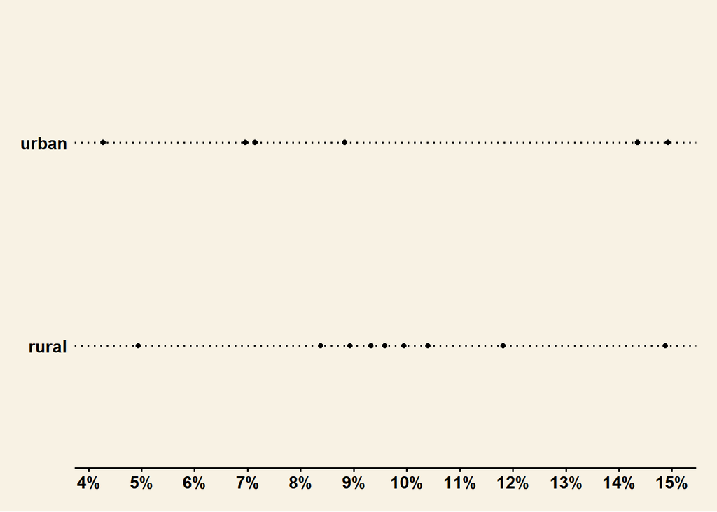

```r
ggplot(Barth_tracts,
       aes(x = pct_vacant,
           y = urban)) +
  geom_point() +
  scale_x_continuous(name = "Percent of housing units vacant",
                     breaks = seq(0, 1, by = 0.01),
                     labels = paste(seq(0, 100, by = 1), "%", sep = "")) +
  scale_y_discrete(name = "",
                    labels = c("rural",
                               "urban")) +
  theme_wsj()
```

## Figure 5 - Scatterplot in Polar Coordinate System with Two Continuous Variables and one categorical variable

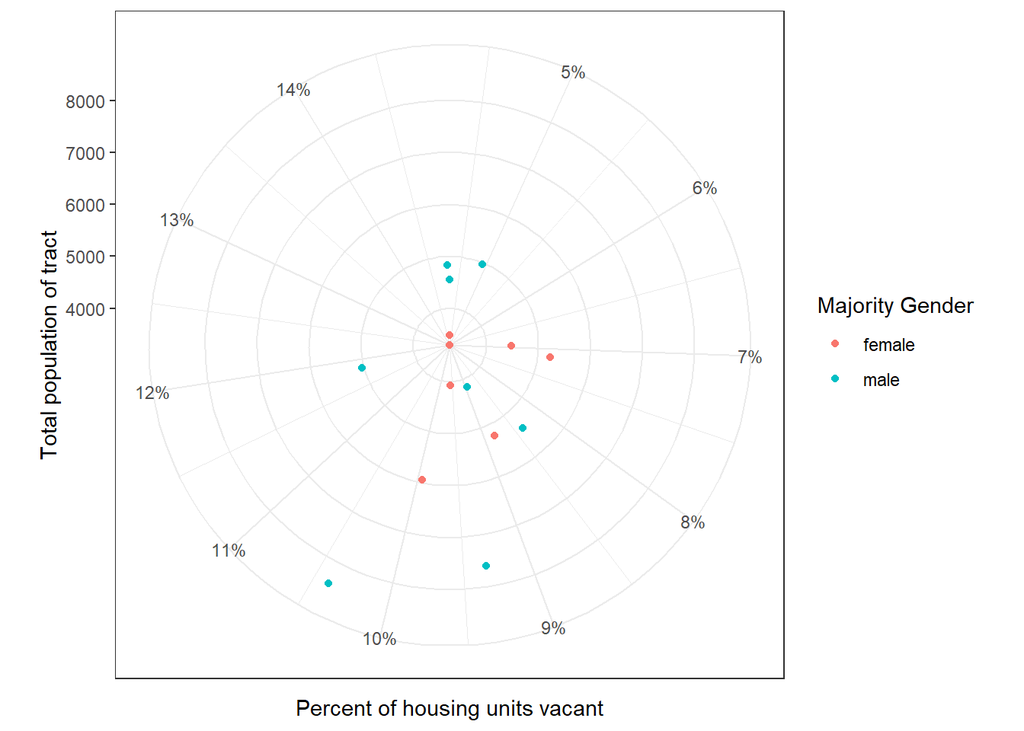

```r
ggplot(Barth_tracts,
       aes(x = pct_vacant,
           y = tot_pop,
           color = majority_gender)) +
  geom_point() +
  scale_x_continuous(name = "Percent of housing units vacant",
                     breaks = seq(0, 1, by = 0.01),
                     labels = paste(seq(0, 100, by = 1), "%", sep = "")) +
  scale_y_continuous(name = "Total population of tract",
                     breaks = seq(1000, 10000, by = 1000)) +
  scale_color_discrete(name = "Majority Gender",
                       labels = c("female", "male")) +
  coord_polar(theta = "x") +
  theme_bw()
```

## Figure 6 - Scatterplot with two continuous variables

[figure not shown]

```r
ggplot(Barth_tracts,
       aes(x = pct_rented,
           y = tot_pop,)) +
  geom_point(size = 4) +
  scale_x_continuous(name = "Percent of housing units vacant",
                     breaks = seq(0, 1, by = 0.05),
                     labels = paste(seq(0, 100, by = 5), "%", sep = "")) +
  scale_y_continuous(name = "Total population of tract",
                     breaks = seq(1000, 10000, by = 1000)) +
  theme_bw() +
  theme(legend.key.size = unit(0.1, "cm"))
```

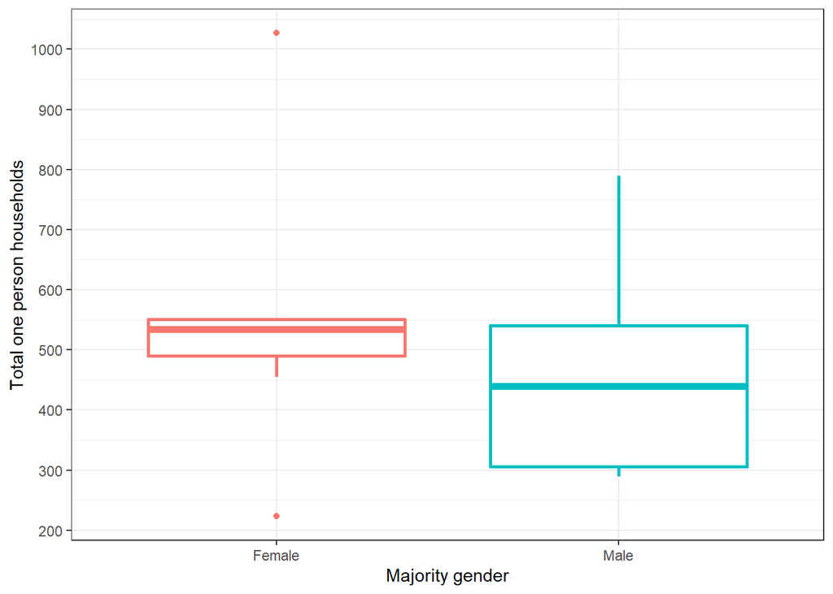

```r
ggplot(Barth_tracts,
       aes(x = majority_gender,
           y = tot_one_person_hh,
           color = majority_gender)) +
  geom_boxplot(size=1) +
  scale_x_discrete(name = "Majority gender",
                       labels = c("Female",
                                  "Male")) +
  scale_y_continuous(name = "Total one person households",
                     breaks = seq(0, 1000, by = 100),
                    labels = paste(seq(0, 1000, by = 100), sep = "")) +
  theme_bw() +
  theme(legend.position = "none")
```

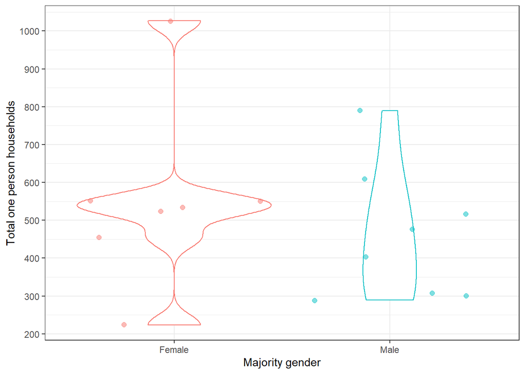

```r
ggplot(Barth_tracts,
       aes(x = majority_gender,
           y = tot_one_person_hh,
           color = majority_gender)) +
  geom_violin() +
  geom_point(position="jitter",
             alpha =0.5,
             size =2) +
  scale_x_discrete(name = "Majority gender",
                       labels = c("Female",
                                  "Male")) +
  scale_y_continuous(name = "Total one person households",
                     breaks = seq(0, 1000, by = 100),
                    labels = paste(seq(0, 1000, by = 100), sep = "")) +
  theme_bw() +
  theme(legend.position = "none")
```

## Figure 9 - Pie chart with one categorical variable

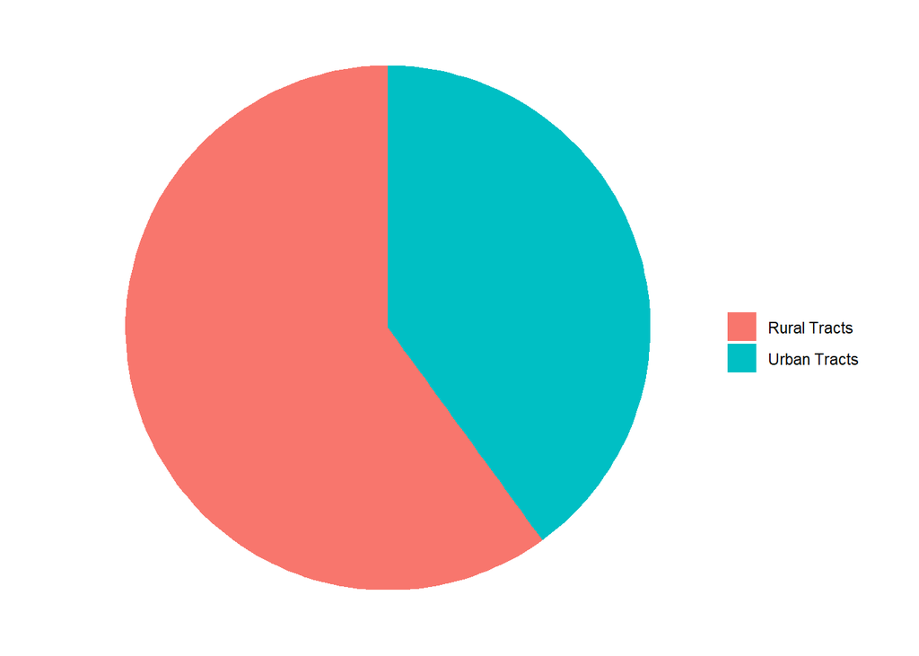

```r
pie_chart <- ggplot(Barth_tracts, aes(x = 1, fill = urban )) +
  geom_bar(position = "fill") +
  coord_polar(theta = "y") +
  scale_y_continuous(name = "Number of tracts") +
  scale_fill_discrete(name = "",
                       labels = c("Rural Tracts",
                                  "Urban Tracts")) +
  theme_void()

pie_chart
```

## Figure 10 - Scatterplot with two continuous variables and one categorical variable with a trendline

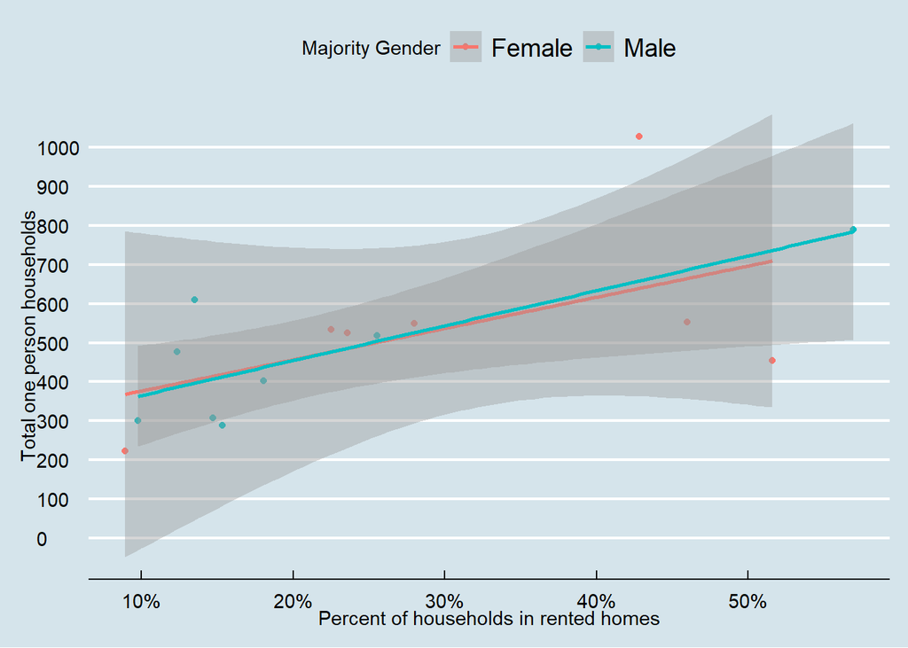

```r
ggplot(Barth_tracts,
       aes(x = pct_rented,
           y = tot_one_person_hh,
           color = majority_gender)) +
  geom_point() +
  stat_smooth(method = "lm") +
  scale_x_continuous(name = "Percent of households in rented homes",
                     breaks = seq(0, 1, by = 0.1),
                     labels = paste(seq(0, 100, by = 10), "%", sep = "")) +
  scale_y_continuous(name = "Total one person households",
                     breaks = seq(0, 1000, by = 100)) +
  scale_color_discrete(name = "Majority Gender",
                       labels = c("Female", "Male")) +
  theme_economist()
```

## Reflections

It was interesting to explore the different ways that R and its various packages can be used to present data. The various styles were especially fun. If I were to do this over again, I would choose a geography that included more census tracts; a greater number of observations would allow for more thorough exploration of the features and challenges R. With this project, as well as the projects for Quant, I continue to feel more comfortable using R.